# Predictions: Theory and Practice

Part II: Market-based Predictions

Patrick Schmidt

University of Heidelberg

# Asset markets as prediction systems

## Motivation

### Asset prices in news

- daily news routinely reports asset prices
  - “the DAX closed 0.7% higher today”
  - “the Euro lost ground against the Dollar”
  - “Oil prices surged after Putin’s interview…”
  - “OpenAI evaluated at 900bn dollars after…”
- but most listeners do not actually trade these assets
- they are treated as informative about the state of the world
- **market prices tell us something about the future**
- we cover
  - which property of the future is being predicted?
  - how reliable is that prediction?

### Which asset prices?

A few examples we will keep in mind:

- **stock price**: claim on future dividends (and resale value of a company)
- **exchange rate**: relative value of two currencies (or the basket of goods one can buy with it)
- **commodity futures**: contract for delivery of oil/wheat/… at a fixed future date
- **bond price**: claim on future interest payments

common structure:

- a price $S_t$ observable today
- a future payoff $Y$ (dividends, exchange rate, delivery price, …)
- price $S_t$ is known
- $Y$ is uncertain $\Rightarrow$ predict with probability distribution
- our question: which property of $Y$ does $S_t$ predict?

## Market prices as mean predictions

### From traders’ beliefs to market prices

- consider an asset with payoff $Y$ at $t+1$, traded at price $S_t$ today
- assume for now: no time value of money, risk-neutral traders (no risk premium), homogeneous beliefs
- a trader with belief $E[Y]$ about the payoff
  - buys if $E[Y] > S_t$
  - sells if $E[Y] < S_t$
- market clears when supply equals demand

$$\Rightarrow S_t = E[Y]$$

- the market price equals the expected payoff

### …modulo some issues

In reality, three things complicate the simple picture $S_t = E[Y]$:

1. **discounting**: money tomorrow $\neq$ money today
   $$S_t = \frac{E[Y]}{1+r}$$
2. **risk premia**: investors are not risk neutral
   $$S_t = \frac{E[Y]}{1+r+\pi}$$
   where $\pi$ is a compensation for bearing risk
3. **heterogeneity in beliefs**: Traders $i = 1,\dots$ may have different mean predictions $E_i[Y]$
   $$S_t = \text{ median of }E_i[Y]$$
   (or wealth weighted if heterogeneous wealth of traders)
- takeaway: price tracks **risk-adjusted** and **wealth-weighted** mean predictions

## The Efficient Market Hypothesis

### Definition

**Efficient Market Hypothesis (EMH)**

A market is **efficient with respect to an information set** $\mathcal{I}$ if asset prices fully reflect that information:
$$S_t = E[\,Y \mid \mathcal{I}\,] \;/\; (1+r+\pi)$$

- equivalently: no trading strategy based on $\mathcal{I}$ earns systematic excess returns
- the “fair game” property: returns conditional on $\mathcal{I}$ are unpredictable beyond the risk-adjusted required return
- different choices of $\mathcal{I}$ give the three forms on the next slide

### Three forms of EMH

(Fama 1970) distinguishes three forms by the information $\mathcal{I}$ that prices reflect:

- **weak form**: $\mathcal{I}$ = past prices
  - implication: returns are unforecastable from past returns
- **semi-strong form**: $\mathcal{I}$ = all public information
  - implication: news is incorporated in prices immediately
- **strong form**: $\mathcal{I}$ = all information (incl. private)
  - implication: even insiders cannot earn excess returns

most empirical work focuses on weak and semi-strong forms.

### Looks like a stock chart?

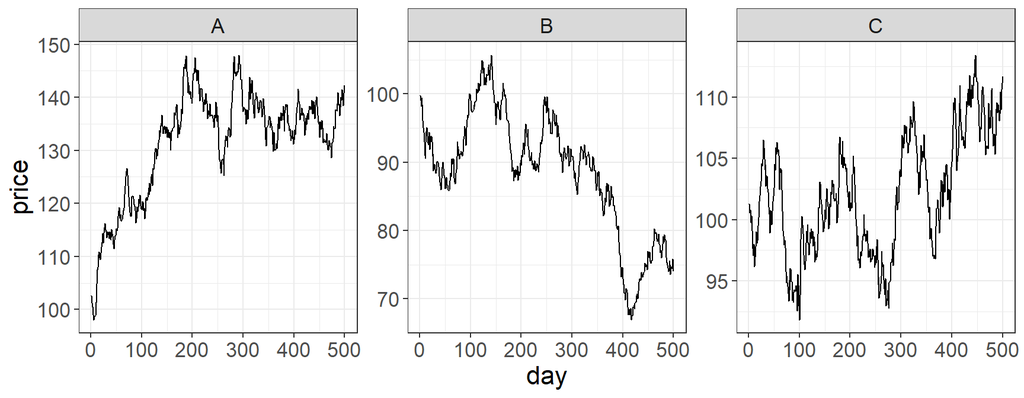

- all three are simulated random walks
- visually indistinguishable from real stock charts
- humans are very good at seeing patterns where there are none
- Efficient market hypothesis implies:
  - Active stock picking and market timing are generally futile
  - Theoretical basis for passive index funds

## Empirical evidence

### Evidence supportive of EMH

- **active managers underperform**
  - most actively managed equity funds are beaten by passive index benchmarks (after fees)
- **event studies**
  - prices react to earnings, M&A, macro news within minutes
  - post-news returns close to zero on average
- **exchange rates: the Meese-Rogoff puzzle** (Meese and Rogoff 1983)
  - structural macro models cannot beat the random walk in out-of-sample forecasts

### Anomalies against EMH

- **post-earnings announcement drift (PEAD)** (Bernard and Thomas 1989)
  - after a positive earnings surprise, returns continue drifting up for 60-90 days
- **momentum** (Jegadeesh and Titman 1993)
  - past 3-12 month winners keep outperforming past losers
- **excess volatility** (Shiller 1981)
  - aggregate stock prices move much more than changes in expected dividends justify

### How to read anomalies

- **joint hypothesis**: Two interpretations of any anomaly:
  1. market is **inefficient** → genuine arbitrage opportunity
  2. asset pricing **model is incomplete** → extra return is compensation for a risk factor we failed to measure
- if arbitrage possible, market will probably correct after publication
  - investors will seek out excess returns, price increases, escess vanishes
- Second option: **inference and multiple testing**
  - anomalies from EMH look like clear statistical results
  - but if many projects study different anomalies, we expect 1 in 10 to be statistically significant at 0.1 $\alpha$-level even if hypothesis true
  - if only this one study is published/catches our attention, inference is flawed

### Why market prices still predict well

even granting the anomalies, market prices remain remarkably hard to beat as predictions:

- **selection**
  - persistently bad traders lose money and exit
  - the surviving population is at least somewhat accurate
- **incentives**
  - capital at risk is a much stronger incentive than answering a survey
  - skin in the game (cf. discussion of judgment forecasts)
- **information aggregation**
  - many participants, diverse private signals
  - prices summarise far more information than any single forecaster has

## Beyond the mean: market-implied uncertainty

### Markets price more than the mean

- so far: market price $S_t \approx E[Y]$
  - market gives us a **point prediction** of the future payoff
- but predictions ideally come with uncertainty
- can markets also reveal **distributional** information?
  - yes with **options**

### Aside: Odd Lots on the VIX

- Bloomberg’s *Odd Lots* podcast
  - Episode: “What Just Happened in Markets? Volatility and the Big Selloff”
  - on Spotify etc.

### What is an option?

- a financial contract whose payoff depends on the future price $S_T$ of an underlying asset
- **European call option** with strike $K$, expiry $T$:
  - right (not obligation) to **buy** the underlying at prize $K$ at time $T$
  - payoff at $T$: $\max(S_T - K, 0)$
- **European put option** with strike $K$, expiry $T$:
  - right to **sell** the underlying for prize $K$ at time $T$
  - payoff at $T$: $\max(K - S_T, 0)$
- actively traded on exchanges (CBOE, Eurex, Eurex…)

### From option prices to implied distributions

- how can we read an implied probability $P$ directly from call prices?
- consider a **call spread**: buy call at $K$, sell call at $K+\Delta K$

$$\text{payoff} = \begin{cases} \Delta K & \text{if } S_T > K+\Delta K \\ S_T - K & \text{if } K < S_T \leq K+\Delta K \\ 0 & \text{if } S_T \leq K \end{cases}$$

- for small $\Delta K$: payoff $\approx \Delta K \cdot \mathbf{1}\{S_T > K\}$
- no-arbitrage pricing: costs = discounted expected payoff
  $$C(K) - C(K+\Delta K) \approx e^{-rT} \cdot E[ \Delta K \cdot \mathbf{1}(S_T > K)]$$

$$e^{rT}\,\frac{C(K) - C(K+\Delta K)}{\Delta K} \approx P(S_T > K)$$

- taking $\Delta K \to 0$ and using $P(S_T \leq K) = 1 - P(S_T > K)$:

$$\boxed{1 + e^{rT}\,\frac{\partial C}{\partial K}=P(S_T \leq K)}$$

- **the CDF of** $S_T$ is directly readable from the slope of the call-price curve
- so option markets give us not just a mean, but an entire **predictive distribution**

### Aside: Similar result for density

**Breeden–Litzenberger (1978)**

The second derivative of the call price $C(K) with respect to strike $K$ recovers the (risk-neutral) density of $S_T$:
$$f_{S_T}(K) = e^{rT} \frac{\partial^2 C(K)}{\partial K^2}$$

### The VIX: a single number for uncertainty

- **Cboe Volatility Index (VIX)**
  - launched 1993, current methodology since 2003
  - aggregates S&P 500 option prices into one number
  - reports market-implied 30-day annualised volatility of the S&P 500
- often called the **“fear gauge”**
  - VIX spikes in crises (e.g., financial crisis 2008, Covid 2020)
  - quoted on daily news as a macro uncertainty indicator
- has become an asset class in its own right
  - VIX futures, options on VIX

[figure not shown]

VIX daily.

### VIX methodology (sketch)

- **realised variance** over $[0,T]$ with $n$ daily log-returns $r_i = \log(S_i/S_{i-1})$:
  $$RV_T = \frac{1}{T}\sum_{t=1}^{T} r_t^2$$
- the price should be
  $$E[e^{rT}RV_T]$$
- VIX is the market’s risk-neutral expectation of 30-day realised variance
- it can be replicated by a portfolio of calls and puts

### VIX as a prediction

- the VIX is a (risk-adjusted) **mean prediction of realised volatility** over the next 30 days
  - target $Y$ = annualised std of S&P 500 returns over $[t, t+30]$
- empirical record (Bollerslev et al. 2009)
  - VIX and subsequent realised vol are highly correlated ($\rho \approx 0.86$)
  - Thus, option prices predict uncertainty succesfully
  - VIX is on average **higher** than the subsequent realised vol
  - Thus, investors pay a premium for protection against volatility spikes

## Wrap-up

### Take-aways

- in an efficient market, the price is a (risk-adjusted) **mean prediction** of future payoffs
- **changes in prices** are unpredictable
  - basis for the random walk model
- empirically:
  - hard to beat market prices on average (exchange rates, fund performance)
  - some documented anomalies
  - interpretation of anomalies limited by the **joint hypothesis problem** and **multiple testing**
- option markets extend this: prices reveal the **distribution** of future outcomes
  - VIX as a market-based uncertainty forecast
- the next section turns to **prediction markets**
  - artificial markets specifically designed to reveal predictions

# Prediction Markets

## Prediction markets

- prediction markets (Arrow et al. 2008)
  - artificial markets with main purpose of revealing information
  - idea: Trade contracts on free market
  - contract pays depending on target variable y
- contrary to standard market prices
  - also reveal information
  - but their primary use/goal is allocation

### Aside:

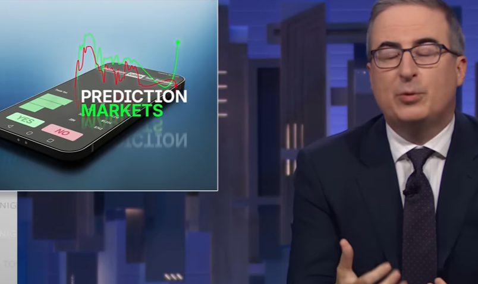

- [Last week tonight by John Oliver on Prediction markets](https://www.youtube.com/watch?v=ZN4njIQcSR4)

### Example prediction market contract

- contract pays 1$ if event happens
- what is its equilibrium price?
- if you belief probability is $p$ you buy if
  $$\begin{align*}
  E_p[\text{money if buy}]&>E_p[\text{money if not buying}]\\
  p \times 1 + (1-p) \times 0 &> price\\
  p &> price
  \end{align*}$$
- market in equilibrium if demand and supply of contracts coincide
  - need as much buyers as sellers of contract
- Thus, equilibrium price connected to beliefs $p$ in market
- “Price in prediction market represents market belief”
  - vague statement that is generally not true
- Can be derived under simplifying assumptions about market participants
  - risk neutral
  - identical wealth
  - heterogenous beliefs $p$
  - then: market equilibrium price = median(p)
- Fails under more realistic assumptions
  - risk averse: participation less likely
  - utility correlated with outcome: hedging
  - homogenous beliefs: no liquidity on market
  - wealth differences: weighted median

### Calculating the margin

- traditional bookmakers quote **odds**, not probabilities
  - decimal odds $o$: a 1$ stake returns $o$$ if you win
  - implied probability of a single outcome: $\hat p = 1/o$
- for a fair market the implied probabilities sum to 1
- bookmakers shade the odds so they sum to **more than 1**:
  $$\text{margin} = \Big(\sum_{k} \tfrac{1}{o_k}\Big) - 1$$
  - the excess is the bookmaker’s expected profit
- example: two equally likely outcomes quoted at $o = 1.91$
  - implied prob each: $1/1.91 \approx 0.5236$
  - sum $\approx 1.0472$ $\Rightarrow$ margin $\approx 4.7\%$

### Prediction markets won’t do Bayesian updating

- nice example from Ottoviani et al.(2015) on updating in prediction markets:
  - hypothetical market based on which team, Italy or Denmark, will win a soccer game
  - traders who are subjectively more optimistic about Italy winning live further south
  - traders living south of a certain threshold latitude invest all their wealth in the asset that pays if Italy wins
  - likewise, traders north of the threshold latitude invest all their wealth in the Denmark asset
- what happens when traders observe information (such as a player injury) more in favor of Italy winning?
  - This information causes the price of the Italy asset to be higher, while contemporaneously reducing the price of the Denmark asset
  - the southern traders (who are optimistic about Italy) are able to buy fewer Italy assets
  - northern traders can afford, and thus demand, more Denmark assets, now cheaper.
  - for the market to equilibrate, some northern traders must turn to the Italian side
- Thus, when information more favorable to an outcome is available, the marginal trader who determines the price has a prior belief that is less favorable to that outcome
  - market adjustment and heterogeneity in priors reduces the effect of information on equilibrium price

### Empirical evidence

- but empirical evidence for prediction markets rather positive
- today routinely covered in media as reference point
  - arguably more representative than experts
- real advantage probably related to selection into participation
  - less accurate market participants unlikely to stay in market
  - incentives for market participants to get more accurate

## Information and Insider trading

### The Grossman-Stiglitz paradox

(Grossman and Stiglitz 1980) point out a tension at the heart of the EMH:

- gathering information is **costly** (research, data, analysis)
- a trader only pays this cost if it lets them earn excess returns
- but if prices **already fully reflect all information**:
  - the informed trader has no advantage
  - nobody bothers to gather information
  - then prices reflect **nothing**
- $\Rightarrow$ a perfectly efficient market is **impossible** (self-contradictory)

### Resolution: partial efficiency

- markets settle at an equilibrium that is efficient *enough*, not perfectly
- prices must stay **slightly mispriced** so that:
  - informed traders earn just enough to cover their information costs
  - this is the “reward” for producing information
- requires some noise (uninformed / liquidity traders)
  - otherwise informed trades instantly reveal the signal and the edge vanishes
- takeaway: a little inefficiency is **necessary**

### Insider trading in normal markets

- in stock/asset markets, **insider trading is illegal**
  - trading on material, non-public information
- why ban something that makes prices more informative?
- main worry: **market liquidity**
  - market makers and uninformed traders systematically lose to insiders
  - this is adverse selection: ask for a trade, and you only get a trade when an insider knows better
  - response: less trades, wider spreads, or even stop of trading
- a market dominated by insiders **dries up**
  - the “lemons” problem of separated market equilibria for liquidity

### Insider trading in prediction markets

- prediction markets exist **precisely to aggregate private information**
- but the people with private information *are* the insiders!
  - the employee who knows the product will ship late
  - the staffer who knows the poll internals
- direct conflict: banning insider trading blocks exactly the information the market is designed to reveal
- the insider’s “unfair advantage” is the **valuable signal** we want in the price
- open question how this develops

# References

Arrow, Kenneth J, Robert Forsythe, Michael Gorham, et al. 2008. “The Promise of Prediction Markets.” In *Science*, No. 5878, vol. 320. American Association for the Advancement of Science.

Bernard, Victor L, and Jacob K Thomas. 1989. “Post-Earnings-Announcement Drift: Delayed Price Response or Risk Premium?” *Journal of Accounting Research* 27: 1–36.

Bollerslev, Tim, George Tauchen, and Hao Zhou. 2009. “Expected Stock Returns and Variance Risk Premia.” *Review of Financial Studies* 22 (11): 4463–92.

Fama, Eugene F. 1970. “Efficient Capital Markets: A Review of Theory and Empirical Work.” *Journal of Finance* 25 (2): 383–417.

Grossman, Sanford J, and Joseph E Stiglitz. 1980. “On the Impossibility of Informationally Efficient Markets.” *The American Economic Review* 70 (3): 393–408.

Jegadeesh, Narasimhan, and Sheridan Titman. 1993. “Returns to Buying Winners and Selling Losers: Implications for Stock Market Efficiency.” *Journal of Finance* 48 (1): 65–91.

Meese, Richard A, and Kenneth Rogoff. 1983. “Empirical Exchange Rate Models of the Seventies: Do They Fit Out of Sample?” *Journal of International Economics* 14 (1–2): 3–24.

Ottaviani, Marco, and Peter Norman Sørensen. 2015. “Price Reaction to Information with Heterogeneous Beliefs and Wealth Effects: Underreaction, Momentum, and Reversal.” *American Economic Review* 105 (1): 01–34.

Shiller, Robert J. 1981. “Do Stock Prices Move Too Much to Be Justified by Subsequent Changes in Dividends?” *American Economic Review* 71 (3): 421–36.